# Simulating and Fitting an SEIR model in JAGS

# Part 1: Simulating from an SEIR model

This document follows on from previous [files](https://hamilton-institute.github.io/covid19-modelling/) that show how to simulate data from an SEIR model. Start by loading in packages

```r
library(R2jags)
library(runjags)
library(mcmcplots)
library(tidyverse)
library(gridExtra)
```

Here is the code to simulate an SEIR model:

```r
seir_sim = '
data {
  # Likelihood
  for (t in 1:T) {
    N_S_E[t] ~ dpois(beta_E * E[t] * S[t] / N)
    N_S_I[t] ~ dpois(beta_I * I[t] * S[t] / N)
    N_E_I[t] ~ dbinom(p_E_I, E[t])
    N_I_R[t] ~ dbinom(p_I_R, I[t])
  }

  # These are the known time evolution steps:
  for(t in 2:T) {
    S[t] = S[t-1] - N_S_E[t-1] - N_S_I[t-1]
    E[t] = E[t-1] + N_S_E[t-1] + N_S_I[t-1] - N_E_I[t-1]
    I[t] = I[t-1] + N_E_I[t-1] - N_I_R[t-1]
    R[t] = R[t-1] + N_I_R[t-1]
  }

  # Need a value for S[1], E[1], and I[1]
  I[1] = I_start
  E[1] = E_start
  R[1] = R_start
  S[1] = N - I[1] - R[1] # Left over

  # Probabilities and R_0
  p_E_I = 1 - exp( - gamma_E )
  p_I_R = 1 - exp( - gamma_I )
  R_0 = (beta_E/gamma_E) + (beta_I/gamma_I)
}
model{
  fake = 0
}
'
```

Now set up the parameters for that model. This has constant R0.

```r
N = 4.9*10^6 # Population size
T = 200 # Maximum time steps

# Length of time exposed
gamma_E_inv = 6.6; gamma_E = 1/gamma_E_inv # Days / Inverse days

# Length of time infected
gamma_I_inv = 7.4; gamma_I = 1/gamma_I_inv

# Transmission rates for Exposed/Infected
beta_E_inv = 5; beta_E = 1/beta_E_inv
beta_I_inv = 5; beta_I = 1/beta_I_inv

# R0 is a function of these values
R_0 = beta_E/gamma_E + beta_I/gamma_I

# Starting values for each component
I_start = 10
E_start = 0
R_start = 0
```

We can then set up a list and use these to simulate data

```r
# parameters are treated as data for the simulation step
data = list(N = N, T = T,
            gamma_E = gamma_E, gamma_I = gamma_I,
            beta_E = beta_E, beta_I = beta_I,
            # These are the starting values for each component
            I_start = I_start, E_start = E_start, R_start = R_start)

# run jags
out = run.jags(seir_sim,
               data = data,
               monitor = c("S", "E", "I", "R"),
               sample = 1, n.chains = 1, summarise=FALSE)
```

```
## Compiling rjags model...
## Calling the simulation using the rjags method...
## Note: the model did not require adaptation
## Burning in the model for 4000 iterations...
## Running the model for 1 iterations...
## Simulation complete
## Finished running the simulation
```

```r
Simulated = coda::as.mcmc(out)
```

This, quite unhelpfully, produces a long vector containing first the S compartment, then the E, then the I, then the R

We can sort it out with:

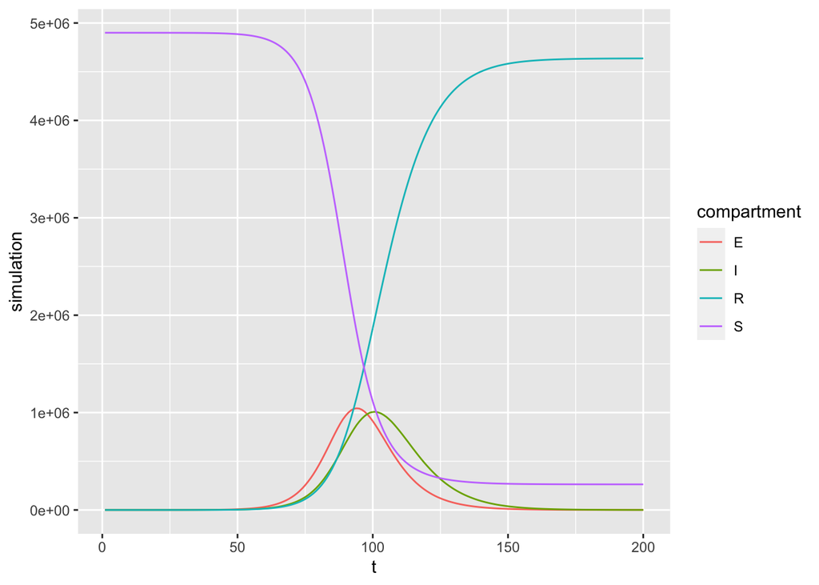

```r
dat = tibble(simulation = as.vector(Simulated))
dat$compartment = c(rep("S",T), rep("E",T), rep("I",T),rep("R",T))
dat$t = rep(1:T, 4)
ggplot(dat, aes(x = t, y = simulation, colour = compartment)) +
  geom_line()
```

It’s interesting how long it takes to hit exponential growth.

# Part 2 Fitting the SEIR model to simulated data

I’m going to do three versions of fitting the model to simulated data:

1. Giving it `N_E_I` and `N_I_R` and the starting values, and see if it can estimate all the other parameters (with good prior distributions)
2. Giving it `N_E_I` and `N_I_R` and the wrong starting values, to see if it can still estimate the other parameters ok
3. Giving it onl `N_E_I` with strong prior distribution on the other parameters and seeing if it can estimate everything else

Here is the JAGS code I will use for fitting these models. The prior distributions at the bottom have fixed hyper-parameters to enable me to control what you can learn or not from the model.

```r
seir_model = '
model {
  # Likelihood
  for (t in 1:T) {
    N_S_E[t] ~ dpois(beta_E * E[t] * S[t] / N)
    N_S_I[t] ~ dpois(beta_I * I[t] * S[t] / N)
    N_E_I[t] ~ dbinom(p_E_I, E[t])
    N_I_R[t] ~ dbinom(p_I_R, I[t])
  }

  # These are the known time evolution steps:
  for(t in 2:T) {
    S[t] = S[t-1] - N_S_E[t-1] - N_S_I[t-1]
    E[t] = E[t-1] + N_S_E[t-1] + N_S_I[t-1] - N_E_I[t-1]
    I[t] = I[t-1] + N_E_I[t-1] - N_I_R[t-1]
    R[t] = R[t-1] + N_I_R[t-1]
  }

  # Need a value for S[1], E[1], and I[1]
  I[1] = I_start
  E[1] = E_start
  R[1] = R_start
  S[1] = N - I[1] - R[1] # Left over

  # Probabilities and R_0
  p_E_I = 1 - exp( - gamma_E )
  p_I_R = 1 - exp( - gamma_I )
  R_0 = (beta_E/gamma_E) + (beta_I/gamma_I)

  # Prior distributions
  gamma_E ~ dgamma(gamma_E_1, gamma_E_2)
  gamma_I ~ dgamma(gamma_I_1, gamma_I_2)
  beta_E ~ dgamma(gamma_beta_E_1, gamma_beta_E_2)
  beta_I ~ dgamma(gamma_beta_I_1, gamma_beta_I_2)
}
'
```

Finally, before starting this exercise, I’m going to simulate the transition data rather than the compartment values from the model:

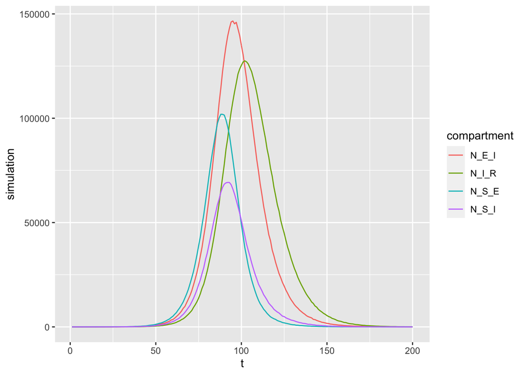

```r
# Simulate what would actually be the data
# set.seed(123)
# out2 = run.jags(seir_sim,
#                 data = data,
#                 monitor = c("N_E_I", "N_I_R", "N_S_E", "N_S_I"),
#                 sample = 1, n.chains = 1, summarise=FALSE)
# saveRDS(out2, file = 'simulated_inputs.rds')
out2 = readRDS(file = 'simulated_inputs.rds')
Simulated2 = coda::as.mcmc(out2)
dat2 = tibble(simulation = as.vector(Simulated2))
dat2$compartment = c(rep("N_E_I",T), rep("N_I_R",T), rep("N_S_E",T),rep("N_S_I",T))
dat2$t = rep(1:T, 4)
ggplot(dat2, aes(x = t, y = simulation, colour = compartment)) +
  geom_line()
```

```r
dat3 = dat2 %>%
  pivot_wider(names_from = compartment, values_from = simulation)
```

## Scenario 1

Giving the model `N_E_I` and `N_I_R` and all the other parameters, and see if it can estimate `N_S_E` and `N_S_I`

```r
fac = 10 # Factor to multiple up the gamma distributions. Larger values give lower sd
jags_run_data = list(N = N, T = T,
                     gamma_E_1 = gamma_E*fac, # These enable me to fix the mean and have small sd
                     gamma_E_2 = fac,
                     gamma_I_1 = gamma_I*fac, # These enable me to fix the mean and have small sd
                     gamma_I_2 = fac,
                     gamma_beta_E_1 = beta_E*fac, # These enable me to fix the mean and have small sd
                     gamma_beta_E_2 = fac,
                     gamma_beta_I_1 = beta_I*fac, # These enable me to fix the mean and have small sd
                     gamma_beta_I_2 = fac,
                     N_E_I = dat3$N_E_I,
                     N_I_R = dat3$N_I_R,
                     # These are the starting values for each component
                     I_start = I_start, E_start = E_start, R_start = R_start)

# Set the starting values to be decent
inits = function() {
  with(dat3,
       list(N_S_E = N_S_E,
            N_S_I = N_S_I))
}

# run jags
# run1 = jags(data = jags_run_data,
#             inits = inits,
#             parameters.to.save = c("N_S_E", "N_S_I", "beta_E", "beta_I", "gamma_E", "gamma_I"),
#             model.file = textConnection(seir_model))
# saveRDS(run1, file = 'jags_run_sier_s1.rds')
run1 = readRDS(file = 'jags_run_sier_s1.rds')
```

That ran very very slowly. See if it converged

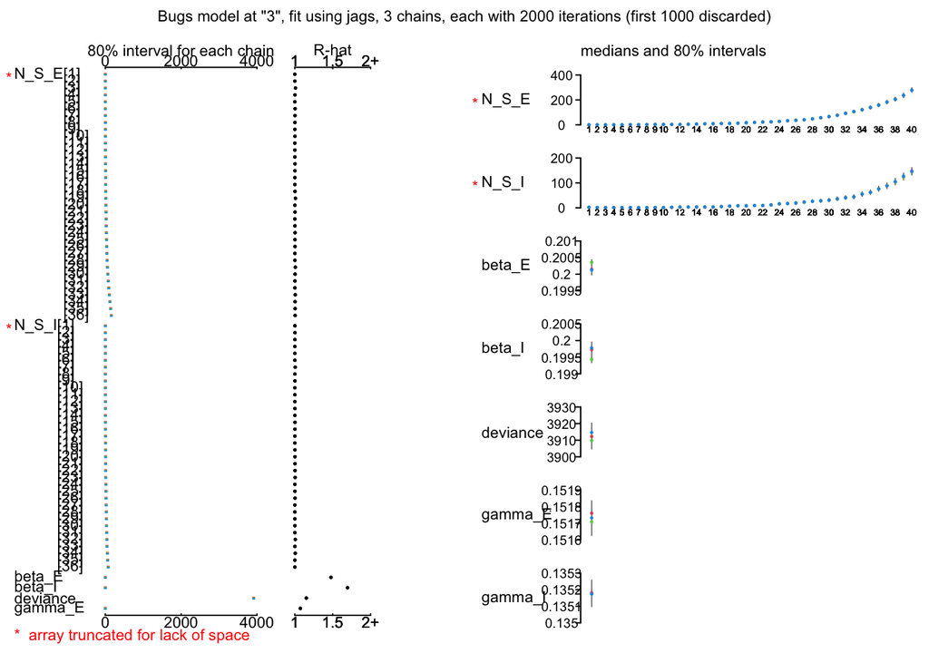

```r
plot(run1)
```

Now see if the values of `N_S_E` and `N_S_I` match the true

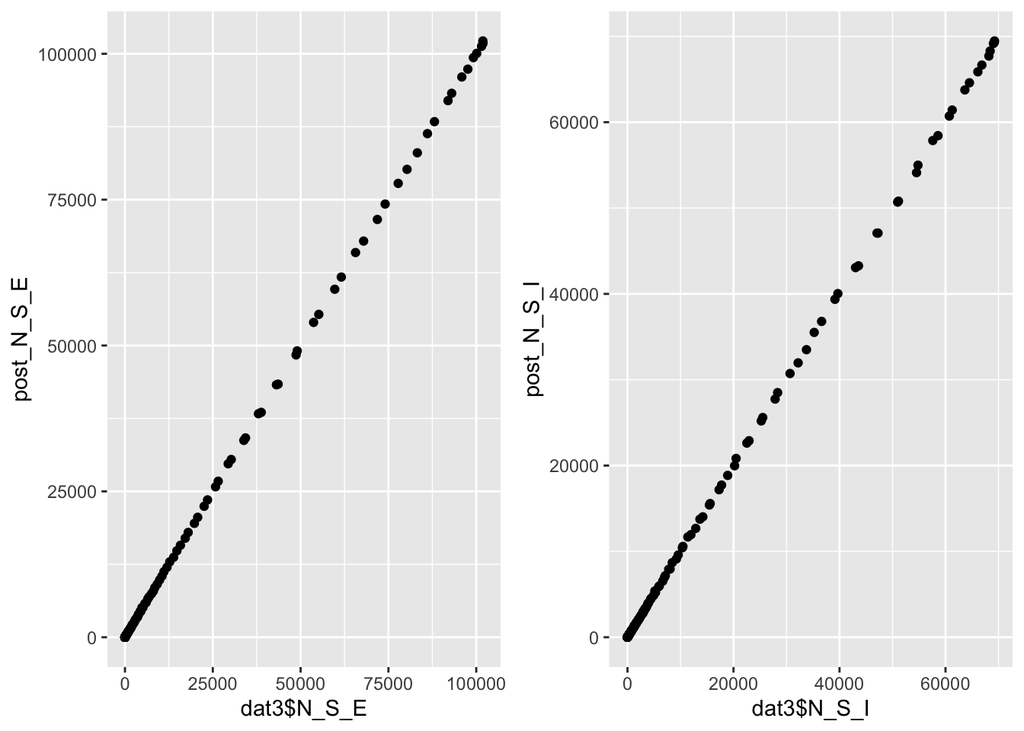

```r
post_N_S_E = run1$BUGSoutput$median$N_S_E
post_N_S_I = run1$BUGSoutput$median$N_S_I

p1 = qplot(dat3$N_S_E, post_N_S_E)
p2 = qplot(dat3$N_S_I, post_N_S_I)
grid.arrange(p1, p2, ncol=2)
```

and see if the parameter values match the truth

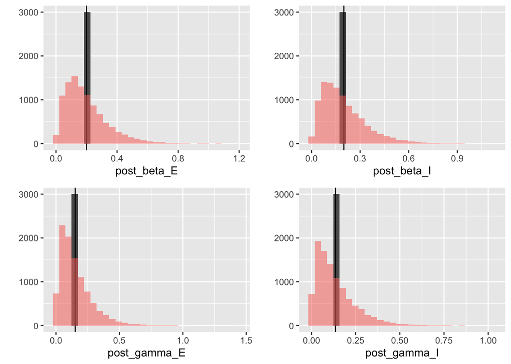

```r
post_beta_E = run1$BUGSoutput$sims.list$beta_E
post_beta_I = run1$BUGSoutput$sims.list$beta_I
post_gamma_E = run1$BUGSoutput$sims.list$gamma_E
post_gamma_I = run1$BUGSoutput$sims.list$gamma_I
p3 = qplot(post_beta_E, geom = 'histogram') +
  geom_vline(xintercept = beta_E) +
  geom_histogram(aes(x = rgamma(10000, beta_E*fac,fac), fill = 'red', alpha = 0.3)) +
  theme(legend.position = 'None')
p4 = qplot(post_beta_I, geom = 'histogram') +
  geom_vline(xintercept = beta_I) +
  geom_histogram(aes(x = rgamma(10000, beta_I*fac,fac), fill = 'red', alpha = 0.3)) +
  theme(legend.position = 'None')
p5 = qplot(post_gamma_E, geom = 'histogram') +
  geom_vline(xintercept = gamma_E) +
  geom_histogram(aes(x = rgamma(10000, gamma_E*fac,fac), fill = 'red', alpha = 0.3)) +
  theme(legend.position = 'None')
p6 = qplot(post_gamma_I, geom = 'histogram') +
  geom_vline(xintercept = gamma_I) +
  geom_histogram(aes(x = rgamma(10000, gamma_I*fac,fac), fill = 'red', alpha = 0.3)) +
  theme(legend.position = 'None')

grid.arrange(p3, p4, p5, p6, ncol=2)
```

Looks pretty good!

## Scenario 2

Now going to give it `N_E_I` and `N_I_R` and the wrong starting values, to see if it can still estimate the other parameters ok.

```r
fac = 10 # Factor to multiple up the gamma distributions. Larger values give lower sd
jags_run_data = list(N = N, T = T,
                     gamma_E_1 = gamma_E*fac, # These enable me to fix the mean and have small sd
                     gamma_E_2 = fac,
                     gamma_I_1 = gamma_I*fac, # These enable me to fix the mean and have small sd
                     gamma_I_2 = fac,
                     gamma_beta_E_1 = beta_E*fac, # These enable me to fix the mean and have small sd
                     gamma_beta_E_2 = fac,
                     gamma_beta_I_1 = beta_I*fac, # These enable me to fix the mean and have small sd
                     gamma_beta_I_2 = fac,
                     N_E_I = dat3$N_E_I,
                     N_I_R = dat3$N_I_R,
                     # These are the starting values for each component - HERE THEY ARE DELIBERATELY SPECIFIED WRONG!
                     I_start = I_start*10, E_start = E_start+10, R_start = R_start  + 100)

# Set the starting values to be decent
inits = function() {
  with(dat3,
       list(N_S_E = N_S_E,
            N_S_I = N_S_I))
}

# Run jags
# run2 = jags(data = jags_run_data,
#             inits = inits,
#             parameters.to.save = c("N_S_E", "N_S_I", "beta_E", "beta_I", "gamma_E", "gamma_I"),
#             model.file = textConnection(seir_model))
# saveRDS(run2, file = 'jags_run_sier_s2.rds')
run2 = readRDS(file = 'jags_run_sier_s2.rds')
```

About 40 minutes to run

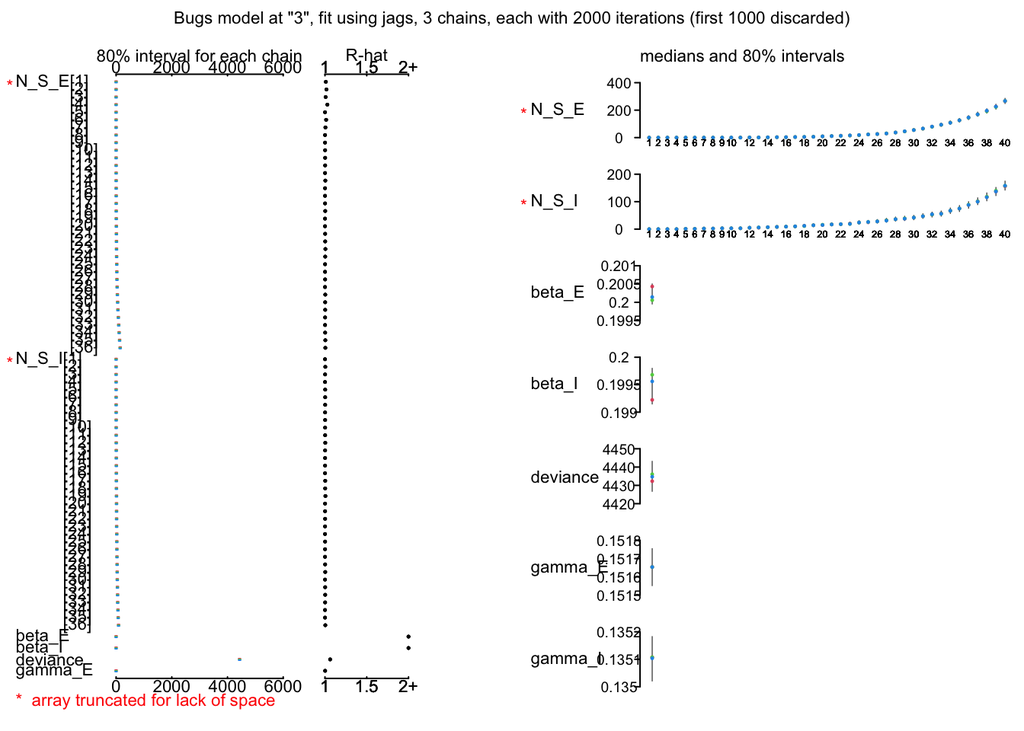

```r
plot(run2)
```

. It did ok but not great convergence of the beta and gamma values. Now see if the values of `N_S_E` and `N_S_I` match the true

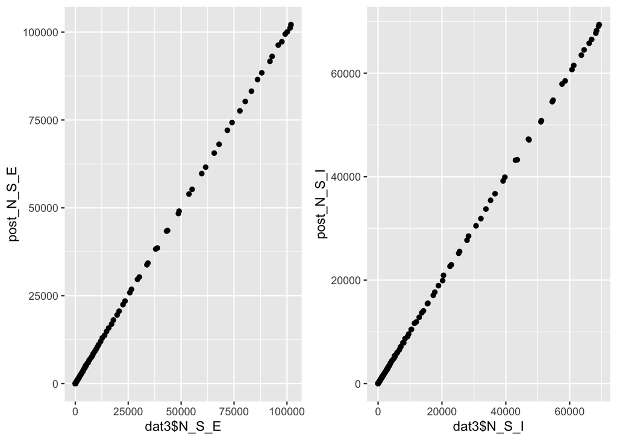

```r
post_N_S_E = run2$BUGSoutput$median$N_S_E
post_N_S_I = run2$BUGSoutput$median$N_S_I

p1 = qplot(dat3$N_S_E, post_N_S_E)
p2 = qplot(dat3$N_S_I, post_N_S_I)
grid.arrange(p1, p2, ncol=2)
```

and see if the parameter values match the truth

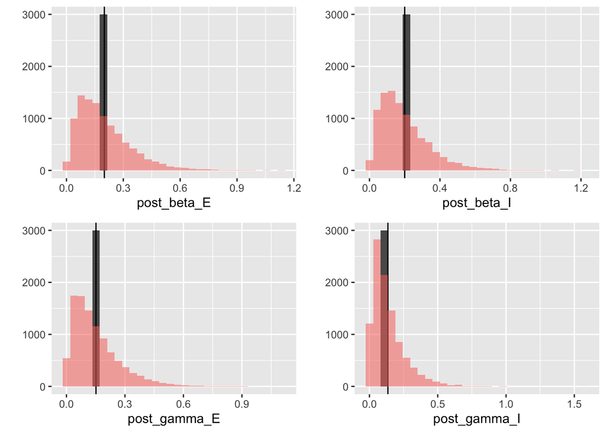

```r
post_beta_E = run2$BUGSoutput$sims.list$beta_E
post_beta_I = run2$BUGSoutput$sims.list$beta_I
post_gamma_E = run2$BUGSoutput$sims.list$gamma_E
post_gamma_I = run2$BUGSoutput$sims.list$gamma_I
p3 = qplot(post_beta_E, geom = 'histogram') +
  geom_vline(xintercept = beta_E) +
  geom_histogram(aes(x = rgamma(10000, beta_E*fac,fac), fill = 'red', alpha = 0.3)) +
  theme(legend.position = 'None')
p4 = qplot(post_beta_I, geom = 'histogram') +
  geom_vline(xintercept = beta_I) +
  geom_histogram(aes(x = rgamma(10000, beta_I*fac,fac), fill = 'red', alpha = 0.3)) +
  theme(legend.position = 'None')
p5 = qplot(post_gamma_E, geom = 'histogram') +
  geom_vline(xintercept = gamma_E) +
  geom_histogram(aes(x = rgamma(10000, gamma_E*fac,fac), fill = 'red', alpha = 0.3)) +
  theme(legend.position = 'None')
p6 = qplot(post_gamma_I, geom = 'histogram') +
  geom_vline(xintercept = gamma_I) +
  geom_histogram(aes(x = rgamma(10000, gamma_I*fac,fac), fill = 'red', alpha = 0.3)) +
  theme(legend.position = 'None')

grid.arrange(p3, p4, p5, p6, ncol=2)
```

## Scenario 3

Finally going to give it only `N_E_I` with strong prior distribution on the other parameters to see if it can estimate everything else

```r
fac = 10 # Factor to multiple up the gamma distributions. Larger values give lower sd
jags_run_data = list(N = N, T = T,
                     gamma_E_1 = gamma_E*fac, # These enable me to fix the mean and have small sd
                     gamma_E_2 = fac,
                     gamma_I_1 = gamma_I*fac, # These enable me to fix the mean and have small sd
                     gamma_I_2 = fac,
                     gamma_beta_E_1 = beta_E*fac, # These enable me to fix the mean and have small sd
                     gamma_beta_E_2 = fac,
                     gamma_beta_I_1 = beta_I*fac, # These enable me to fix the mean and have small sd
                     gamma_beta_I_2 = fac,
                     N_E_I = dat3$N_E_I,
                     # These are the starting values for each component - HERE THEY ARE DELIBERATELY SPECIFIED WRONG!
                     I_start = I_start, E_start = E_start, R_start = R_start)

# Set the starting values to be decent
inits = function() {
  with(dat3,
       list(N_S_E = N_S_E,
            N_I_R = N_I_R,
            N_S_I = N_S_I))
}

# Run jags
# run3 = jags(data = jags_run_data,
#             inits = inits,
#             parameters.to.save = c("N_S_E", "N_S_I", "N_I_R", "beta_E", "beta_I", "gamma_E", "gamma_I"),
#             model.file = textConnection(seir_model))
# saveRDS(run3, file = 'jags_run_sier_s3.rds')
run3 = readRDS(file = 'jags_run_sier_s3.rds')
```

About 40 minutes to run

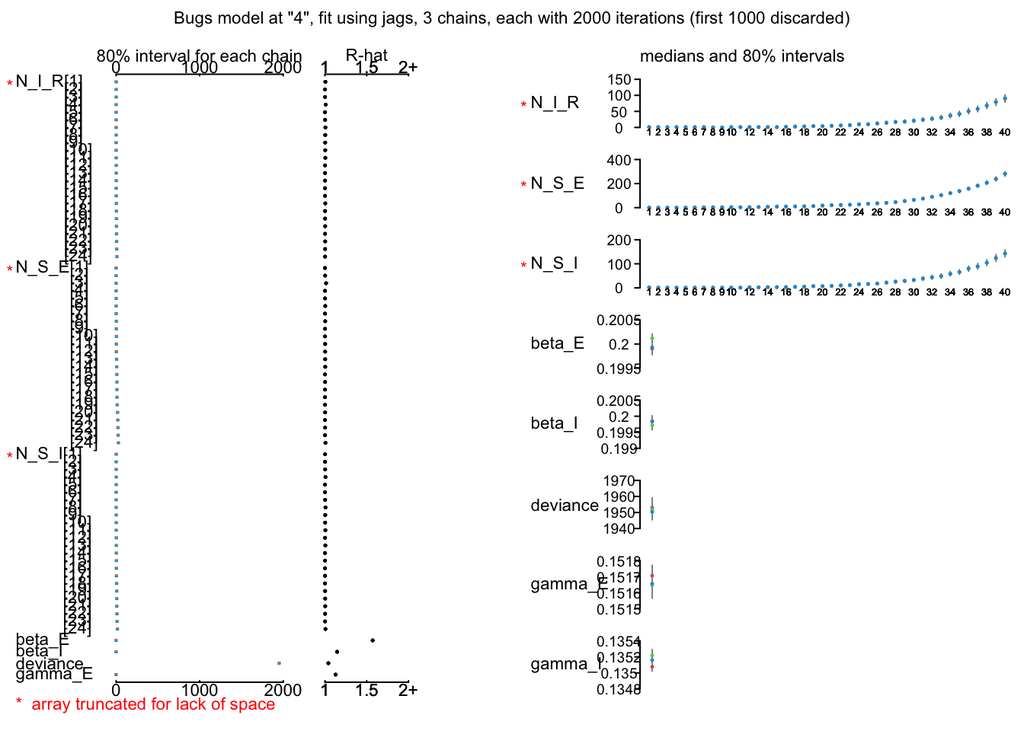

```r
plot(run3)
```

. It did ok but not great convergence of the beta and gamma values. Now see if the values of `N_S_E` and `N_S_I` match the true

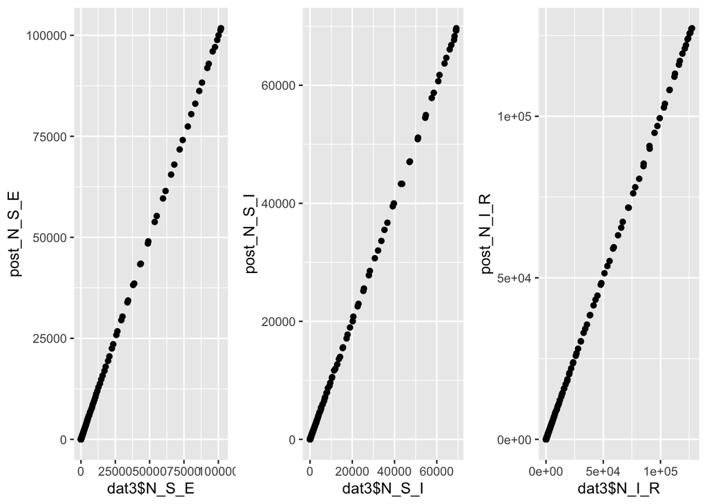

```r
post_N_S_E = run3$BUGSoutput$median$N_S_E
post_N_S_I = run3$BUGSoutput$median$N_S_I
post_N_I_R = run3$BUGSoutput$median$N_I_R

p1 = qplot(dat3$N_S_E, post_N_S_E)
p2 = qplot(dat3$N_S_I, post_N_S_I)
p3 = qplot(dat3$N_I_R, post_N_I_R)
grid.arrange(p1, p2, p3, ncol=3)
```

and see if the parameter values match the truth

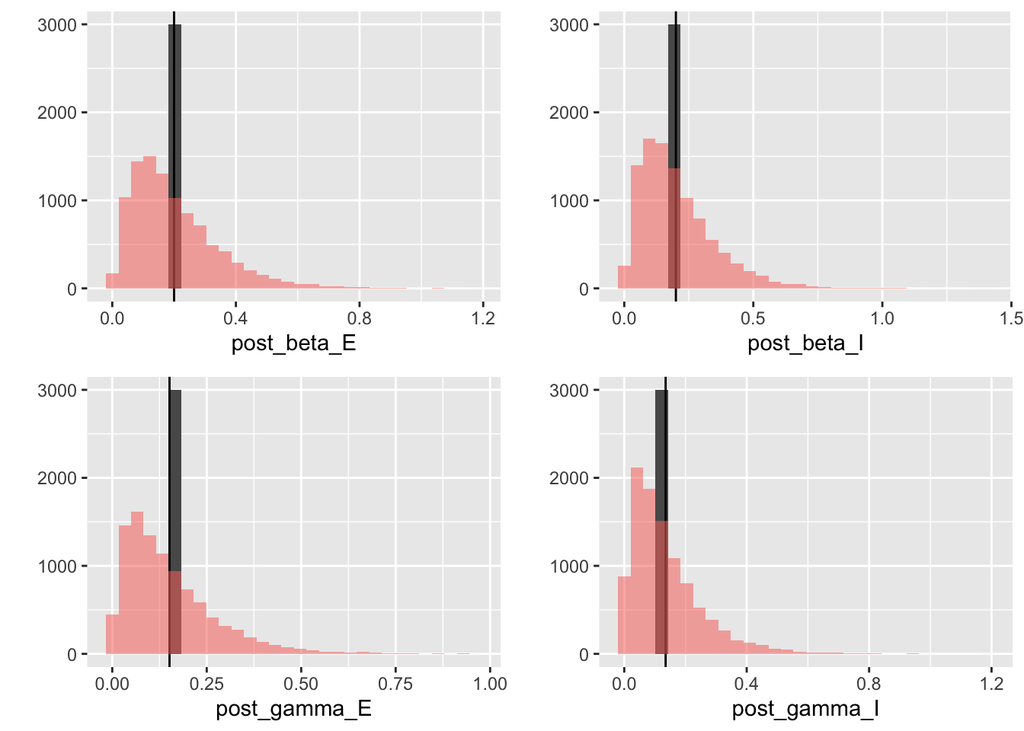

```r
post_beta_E = run2$BUGSoutput$sims.list$beta_E
post_beta_I = run2$BUGSoutput$sims.list$beta_I
post_gamma_E = run2$BUGSoutput$sims.list$gamma_E
post_gamma_I = run2$BUGSoutput$sims.list$gamma_I
p3 = qplot(post_beta_E, geom = 'histogram') +
  geom_vline(xintercept = beta_E) +
  geom_histogram(aes(x = rgamma(10000, beta_E*fac,fac), fill = 'red', alpha = 0.3)) +
  theme(legend.position = 'None')
p4 = qplot(post_beta_I, geom = 'histogram') +
  geom_vline(xintercept = beta_I) +
  geom_histogram(aes(x = rgamma(10000, beta_I*fac,fac), fill = 'red', alpha = 0.3)) +
  theme(legend.position = 'None')
p5 = qplot(post_gamma_E, geom = 'histogram') +
  geom_vline(xintercept = gamma_E) +
  geom_histogram(aes(x = rgamma(10000, gamma_E*fac,fac), fill = 'red', alpha = 0.3)) +
  theme(legend.position = 'None')
p6 = qplot(post_gamma_I, geom = 'histogram') +
  geom_vline(xintercept = gamma_I) +
  geom_histogram(aes(x = rgamma(10000, gamma_I*fac,fac), fill = 'red', alpha = 0.3)) +
  theme(legend.position = 'None')

grid.arrange(p3, p4, p5, p6, ncol=2)
```